# **Predict Future Sales**

## **Name: C Koushik**

## **Reg.No: 18BCE1227**

## **Dataset: Predict Future Sales- Kaggle**

## **Source: https://www.kaggle.com/c/competitive-data-science-predict-future-sales**

## **Description of Dataset**

You are provided with daily historical sales data. The task is to forecast the total amount of products sold in every shop for the test set. Note that the list of shops and products slightly changes every month. Creating a robust model that can handle such situations is part of the challenge.

### **File descriptions**

sales_train.csv - the training set. Daily historical data from January 2013 to October 2015.  
test.csv - the test set. You need to forecast the sales for these shops and products for November 2015.  
sample_submission.csv - a sample submission file in the correct format.  
items.csv - supplemental information about the items/products.  
item_categories.csv - supplemental information about the items categories.  
shops.csv- supplemental information about the shops.

### **Data fields**

ID - an Id that represents a (Shop, Item) tuple within the test set  
shop_id - unique identifier of a shop  
item_id - unique identifier of a product  
item_category_id - unique identifier of item category  
item_cnt_day - number of products sold. You are predicting a monthly amount of this measure  
item_price - current price of an item  
date - date in format dd/mm/yyyy  
date_block_num - a consecutive month number, used for convenience. January 2013 is 0, February 2013 is 1,…, October 2015 is 33  
item_name - name of item  
shop_name - name of shop  
item_category_name - name of item category

## **Work Progress(Proposed work)**

**Review 1 :** Chose topic and dataset, explained its nature. Performed basic commands to describe datasets and kept it ready for review 2.

**Review 2 :** Explored the dataset, performed visualizations and deep analysis of each attribute in a top-down approach and displayed a time series chart to analyze the pattern of sales of products over the years in shops.

**Review 3:** Performed time series analysis, approximately predicted sales line for November 2015.

Importing packages

```r
library(dplyr)
```

```r
library(ggplot2)
library(scales)
library(lubridate)
```

Reading dataset and basic commands

```r
df_train<-read.csv("C:\\Users\\luxcee99\\Downloads\\sales_train.csv")
head(df_train)
```

```
##         date date_block_num shop_id item_id item_price item_cnt_day
## 1 02.01.2013              0      59   22154     999.00            1
## 2 03.01.2013              0      25    2552     899.00            1
## 3 05.01.2013              0      25    2552     899.00           -1
## 4 06.01.2013              0      25    2554    1709.05            1
## 5 15.01.2013              0      25    2555    1099.00            1
## 6 10.01.2013              0      25    2564     349.00            1
```

```r
dim(df_train)
```

```
## [1] 2935849       6
```

```r
typeof(df_train)
```

```
## [1] "list"
```

```r
class(df_train)
```

```
## [1] "data.frame"
```

**For further analysis we require more details of items in the dataset. Therefore, I have joined columns from items.csv to the training dataset using left join operation.**

We need item_category_id from items.csv which is important

```r
df_items<-read.csv("C:\\Users\\luxcee99\\Downloads\\items.csv")
df_sales=df_train %>% left_join(df_items,by=c("item_id"))
df_sales$item_name<-NULL
head(df_sales)
```

```
##         date date_block_num shop_id item_id item_price item_cnt_day
## 1 02.01.2013              0      59   22154     999.00            1
## 2 03.01.2013              0      25    2552     899.00            1
## 3 05.01.2013              0      25    2552     899.00           -1
## 4 06.01.2013              0      25    2554    1709.05            1
## 5 15.01.2013              0      25    2555    1099.00            1
## 6 10.01.2013              0      25    2564     349.00            1
##   item_category_id
## 1               37
## 2               58
## 3               58
## 4               58
## 5               56
## 6               59
```

```r
rm(df_train)
rm(df_items)
```

```r
glimpse(df_sales)
```

```
## Rows: 2,935,849
## Columns: 7
## $ date             <chr> "02.01.2013", "03.01.2013", "05.01.2013", "06.01.2...
## $ date_block_num   <int> 0, 0, 0, 0, 0, 0, 0, 0, 0, 0, 0, 0, 0, 0, 0, 0, 0,...
## $ shop_id          <int> 59, 25, 25, 25, 25, 25, 25, 25, 25, 25, 25, 25, 25...
## $ item_id          <int> 22154, 2552, 2552, 2554, 2555, 2564, 2565, 2572, 2...
## $ item_price       <dbl> 999.00, 899.00, 899.00, 1709.05, 1099.00, 349.00, ...
## $ item_cnt_day     <dbl> 1, 1, -1, 1, 1, 1, 1, 1, 1, 3, 2, 1, 1, 2, 1, 2, 1...
## $ item_category_id <int> 37, 58, 58, 58, 56, 59, 56, 55, 55, 55, 55, 55, 55...
```

### **Data preparation**

```r
#converting date column from character to date format
df_sales$date=dmy(df_sales$date)
```

**To explore and analyze data in a top-down manner, we split the date into year, month, day and weekday. Performing feature engineering**

```r
df_sales$year<-year(df_sales$date)
df_sales$month<-month(df_sales$date)
df_sales$day<-day(df_sales$date)
df_sales$weekday<-weekdays(df_sales$date)
```

**there are only 3 years (2013,2014 and 2015) in total and 7 days in a week, we convert the columns ‘year’ and ‘weekday’ into factors**

```r
df_sales$year<-as.factor(df_sales$year)
df_sales$weekday<-as.factor(df_sales$weekday)
```

**As the task is to predict the total amount of products sold in every shop for November 2015, I’ll have to find out how many items were sold per month in every shop**

```r
df_sales<-df_sales%>%group_by(year,month,shop_id,item_id)%>%mutate(item_cnt_month=sum(item_cnt_day))
head(df_sales)
```

```
## # A tibble: 6 x 12
## # Groups:   year, month, shop_id, item_id [5]
##   date       date_block_num shop_id item_id item_price item_cnt_day
##   <date>              <int>   <int>   <int>      <dbl>        <dbl>
## 1 2013-01-02              0      59   22154       999             1
## 2 2013-01-03              0      25    2552       899             1
## 3 2013-01-05              0      25    2552       899            -1
## 4 2013-01-06              0      25    2554      1709.            1
## 5 2013-01-15              0      25    2555      1099             1
## 6 2013-01-10              0      25    2564       349             1
## # ... with 6 more variables: item_category_id <int>, year <fct>, month <dbl>,
## #   day <int>, weekday <fct>, item_cnt_month <dbl>
```

```r
glimpse(df_sales)
```

```
## Rows: 2,935,849
## Columns: 12
## Groups: year, month, shop_id, item_id [1,609,124]
## $ date             <date> 2013-01-02, 2013-01-03, 2013-01-05, 2013-01-06, 2...
## $ date_block_num   <int> 0, 0, 0, 0, 0, 0, 0, 0, 0, 0, 0, 0, 0, 0, 0, 0, 0,...
## $ shop_id          <int> 59, 25, 25, 25, 25, 25, 25, 25, 25, 25, 25, 25, 25...
## $ item_id          <int> 22154, 2552, 2552, 2554, 2555, 2564, 2565, 2572, 2...
## $ item_price       <dbl> 999.00, 899.00, 899.00, 1709.05, 1099.00, 349.00, ...
## $ item_cnt_day     <dbl> 1, 1, -1, 1, 1, 1, 1, 1, 1, 3, 2, 1, 1, 2, 1, 2, 1...
## $ item_category_id <int> 37, 58, 58, 58, 56, 59, 56, 55, 55, 55, 55, 55, 55...
## $ year             <fct> 2013, 2013, 2013, 2013, 2013, 2013, 2013, 2013, 20...
## $ month            <dbl> 1, 1, 1, 1, 1, 1, 1, 1, 1, 1, 1, 1, 1, 1, 1, 1, 1,...
## $ day              <int> 2, 3, 5, 6, 15, 10, 2, 4, 11, 3, 3, 5, 7, 8, 10, 1...
## $ weekday          <fct> Wednesday, Thursday, Saturday, Sunday, Tuesday, Th...
## $ item_cnt_month   <dbl> 1, 0, 0, 1, 1, 1, 1, 2, 2, 3, 13, 13, 13, 13, 13, ...
```

```r
summary(df_sales)
```

```
##       date            date_block_num     shop_id      item_id
##  Min.   :2013-01-01   Min.   : 0.00   Min.   : 0   Min.   :    0
##  1st Qu.:2013-08-01   1st Qu.: 7.00   1st Qu.:22   1st Qu.: 4476
##  Median :2014-03-04   Median :14.00   Median :31   Median : 9343
##  Mean   :2014-04-03   Mean   :14.57   Mean   :33   Mean   :10197
##  3rd Qu.:2014-12-05   3rd Qu.:23.00   3rd Qu.:47   3rd Qu.:15684
##  Max.   :2015-10-31   Max.   :33.00   Max.   :59   Max.   :22169
##
##    item_price        item_cnt_day      item_category_id   year
##  Min.   :    -1.0   Min.   : -22.000   Min.   : 0       2013:1267562
##  1st Qu.:   249.0   1st Qu.:   1.000   1st Qu.:28       2014:1055861
##  Median :   399.0   Median :   1.000   Median :40       2015: 612426
##  Mean   :   890.9   Mean   :   1.243   Mean   :40
##  3rd Qu.:   999.0   3rd Qu.:   1.000   3rd Qu.:55
##  Max.   :307980.0   Max.   :2169.000   Max.   :83
##
##      month             day             weekday       item_cnt_month
##  Min.   : 1.000   Min.   : 1.00   Friday   :439298   Min.   : -22.000
##  1st Qu.: 3.000   1st Qu.: 8.00   Monday   :337074   1st Qu.:   1.000
##  Median : 6.000   Median :16.00   Saturday :590359   Median :   2.000
##  Mean   : 6.248   Mean   :15.85   Sunday   :503104   Mean   :   7.401
##  3rd Qu.: 9.000   3rd Qu.:24.00   Thursday :367280   3rd Qu.:   5.000
##  Max.   :12.000   Max.   :31.00   Tuesday  :345772   Max.   :2253.000
##                                   Wednesday:352962
```

Checking for missing data in each column

```r
cbind(colSums(is.na(df_sales)))
```

```
##                  [,1]
## date                0
## date_block_num      0
## shop_id             0
## item_id             0
## item_price          0
## item_cnt_day        0
## item_category_id    0
## year                0
## month               0
## day                 0
## weekday             0
## item_cnt_month      0
```

```r
is.null(df_sales)
```

```
## [1] FALSE
```

**There are no missing/null/na values in the dataset**

### **Exploratory Data Analysis**

**Total number of unique shops**

```r
n_distinct(df_sales$shop_id)
```

```
## [1] 60
```

**Total number of unique items in various shops**

```r
n_distinct(df_sales$item_id)
```

```
## [1] 21807
```

**Total number of unique item categories**

```r
n_distinct(df_sales$item_category_id)
```

```
## [1] 84
```

**Shops and number of items in that shop**

```r
most_items=df_sales%>%group_by(shop_id)%>%summarize(total_items_per_shop=n_distinct(item_id))%>%arrange(desc(total_items_per_shop))%>%head(15)%>%ungroup()
head(most_items)
```

```
## # A tibble: 6 x 2
##   shop_id total_items_per_shop
##     <int>                <int>
## 1      25                15367
## 2      31                14416
## 3      54                13863
## 4      28                12572
## 5      57                12281
## 6      42                12034
```

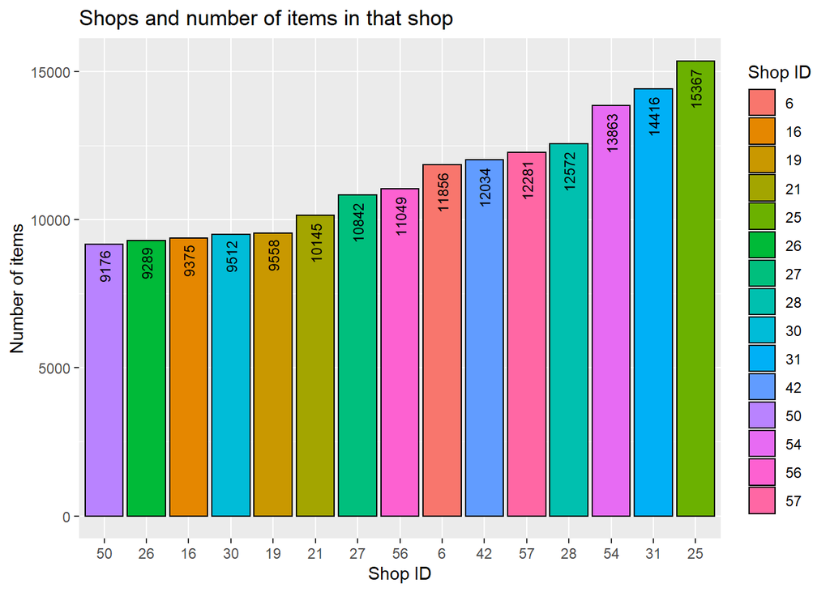

```r
#Visualization
ggplot(data=most_items,aes(x=reorder(as.factor(shop_id),total_items_per_shop),y=total_items_per_shop,fill=as.factor(shop_id)))+
  geom_bar(stat="identity",color="Black")+
  labs(title="Shops and number of items in that shop",x="Shop ID",y="Number of items",fill="Shop ID")+
  geom_text(aes(label=total_items_per_shop),size=3,angle=90,hjust=1.2)
```

**Shop no. 25 has the most number of items (15367)**

**Most sold item in shops**

```r
most_sold_item=df_sales%>%group_by(shop_id,item_id)%>%summarize(most_sold_item_cnt=sum(item_cnt_day))%>%filter(most_sold_item_cnt==max(most_sold_item_cnt))%>%arrange(desc(most_sold_item_cnt))%>%head(15)
head(most_sold_item,10)
```

```
## # A tibble: 10 x 3
## # Groups:   shop_id [10]
##    shop_id item_id most_sold_item_cnt
##      <int>   <int>              <dbl>
##  1      31   20949              19934
##  2      25   20949              14343
##  3      28   20949              13458
##  4      54   20949              12323
##  5      42   20949              10514
##  6      27   20949               8265
##  7      12   11373               6563
##  8      57   20949               6116
##  9      47   20949               4530
## 10      22   20949               4382
```

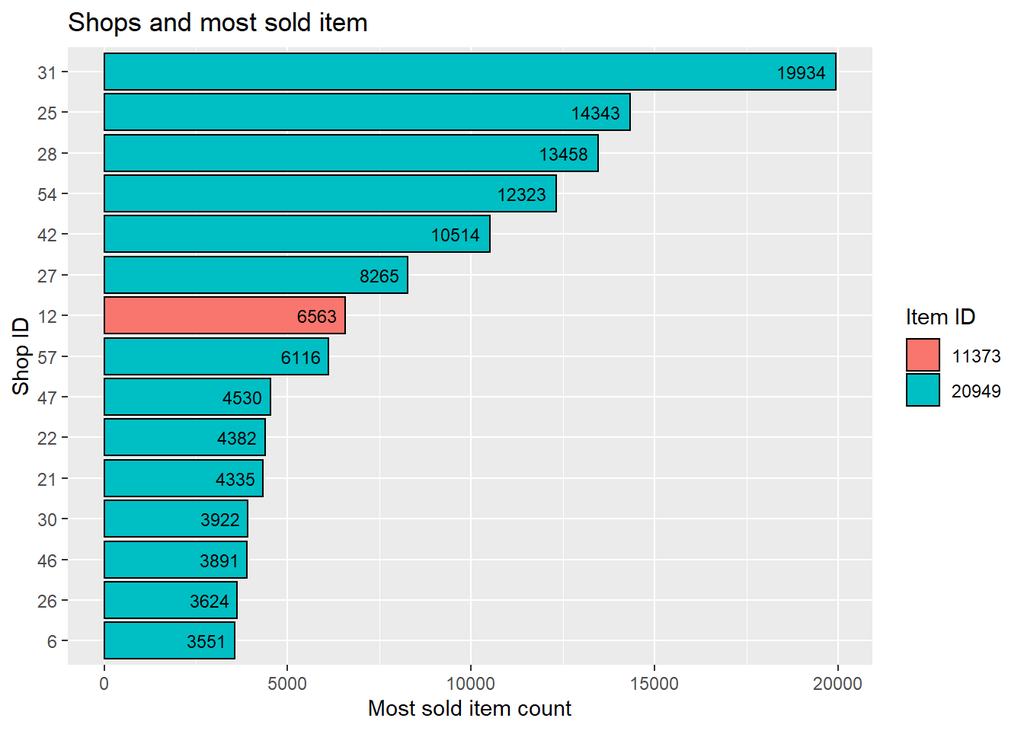

```r
#Visualization
ggplot(data=most_sold_item,aes(x=reorder(as.factor(shop_id),most_sold_item_cnt),y=most_sold_item_cnt,fill=as.factor(item_id)))+
  geom_bar(stat="identity",color="Black")+
  coord_flip()+
  labs(title="Shops and most sold item",x="Shop ID",y="Most sold item count",fill="Item ID")+
  geom_text(aes(label=most_sold_item_cnt),size=3,hjust=1.2)
```

**Item no. 20949 is the most sold item across almost every shop and is most sold in shop 31 (19934 items)**

**Shops and their total count of item categories**

```r
most_categories_shop=df_sales%>%group_by(shop_id)%>%summarize(total_categories_in_shop=n_distinct(item_category_id))%>%arrange(desc(total_categories_in_shop)) %>% head(15)%>%ungroup()
head(most_categories_shop,10)
```

```
## # A tibble: 10 x 2
##    shop_id total_categories_in_shop
##      <int>                    <int>
##  1      25                       65
##  2      12                       64
##  3       6                       63
##  4      16                       63
##  5      37                       63
##  6      38                       63
##  7      56                       63
##  8      18                       62
##  9      31                       62
## 10      35                       62
```

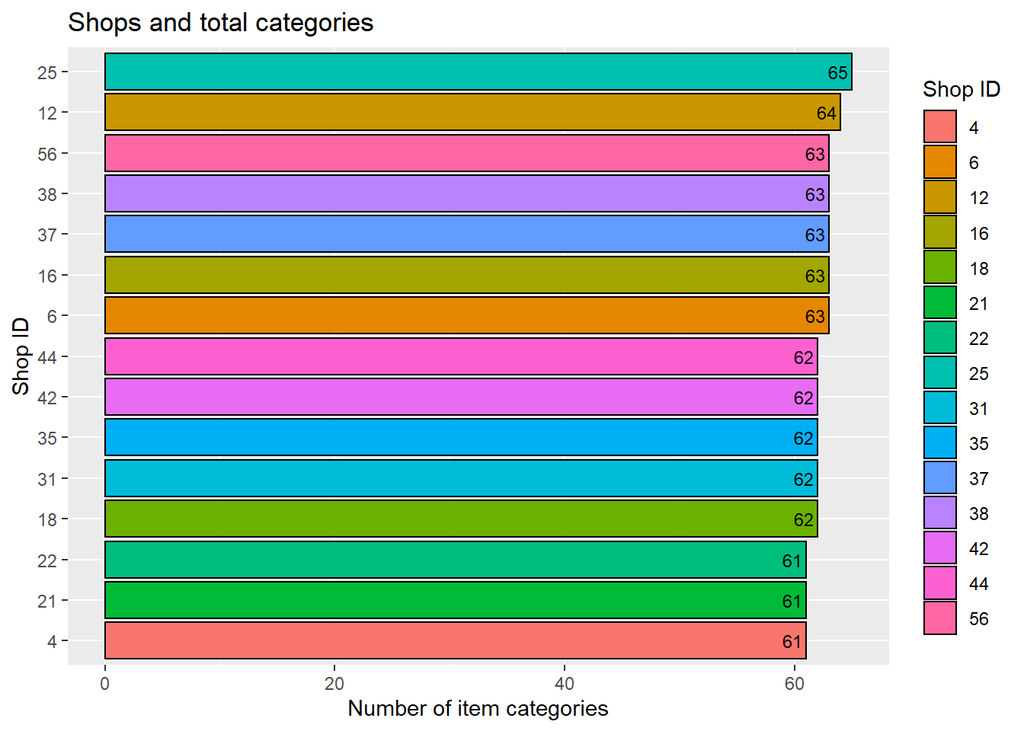

```r
#Visualization
ggplot(data=most_categories_shop,aes(x=reorder(as.factor(shop_id),total_categories_in_shop),y=total_categories_in_shop,fill=as.factor(shop_id)))+
  geom_bar(stat="identity",color="Black")+coord_flip()+
  labs(title="Shops and total categories",x="Shop ID",y="Number of item categories",fill="Shop ID")+
  geom_text(aes(label=total_categories_in_shop),size=3,hjust=1.2)
```

**Shop 25 has the most number of item categories (65 categories)**

**To find out which item category is most popular in terms of sales**

```r
most_sold_category=df_sales%>%group_by(shop_id,item_category_id)%>%summarize(most_sold_category_cnt=sum(item_cnt_day))%>% filter(most_sold_category_cnt==max(most_sold_category_cnt))%>%arrange(desc(most_sold_category_cnt))%>% head(15)%>%ungroup()
head(most_sold_category,10)
```

```
## # A tibble: 10 x 3
##    shop_id item_category_id most_sold_category_cnt
##      <int>            <int>                  <dbl>
##  1      31               40                  76069
##  2      25               40                  45176
##  3      54               40                  44904
##  4      57               40                  44589
##  5      28               40                  38588
##  6      55               31                  35108
##  7      58               40                  25663
##  8      42               40                  22179
##  9      56               40                  21463
## 10      12                9                  18118
```

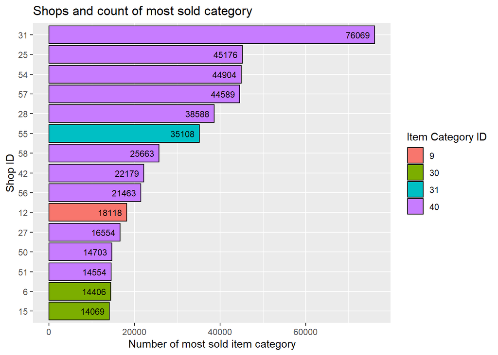

```r
#Visualization
ggplot(data=most_sold_category,aes(x=reorder(as.factor(shop_id),most_sold_category_cnt),y=most_sold_category_cnt,fill=as.factor(item_category_id)))+
  geom_bar(stat="identity",color="Black")+coord_flip()+
  labs(title="Shops and count of most sold category ",x="Shop ID",y="Number of most sold item category",fill="Item Category ID")+
  geom_text(aes(label=most_sold_category_cnt),size=3,hjust=1.2)
```

**Category 40 is the most sold item category in almost all the shops with highest sales in shop 31 (76069 products sold in category 40)**

**Shops and their total number of sales**

```r
most_sales_shop=df_sales%>%group_by(shop_id)%>%summarize(most_sales_shop_cnt=n())%>%arrange(desc(most_sales_shop_cnt))%>%head(15)%>%ungroup()
head(most_sales_shop,10)
```

```
## # A tibble: 10 x 2
##    shop_id most_sales_shop_cnt
##      <int>               <int>
##  1      31              235636
##  2      25              186104
##  3      54              143480
##  4      28              142234
##  5      57              117428
##  6      42              109253
##  7      27              105366
##  8       6               82663
##  9      58               71441
## 10      56               69573
```

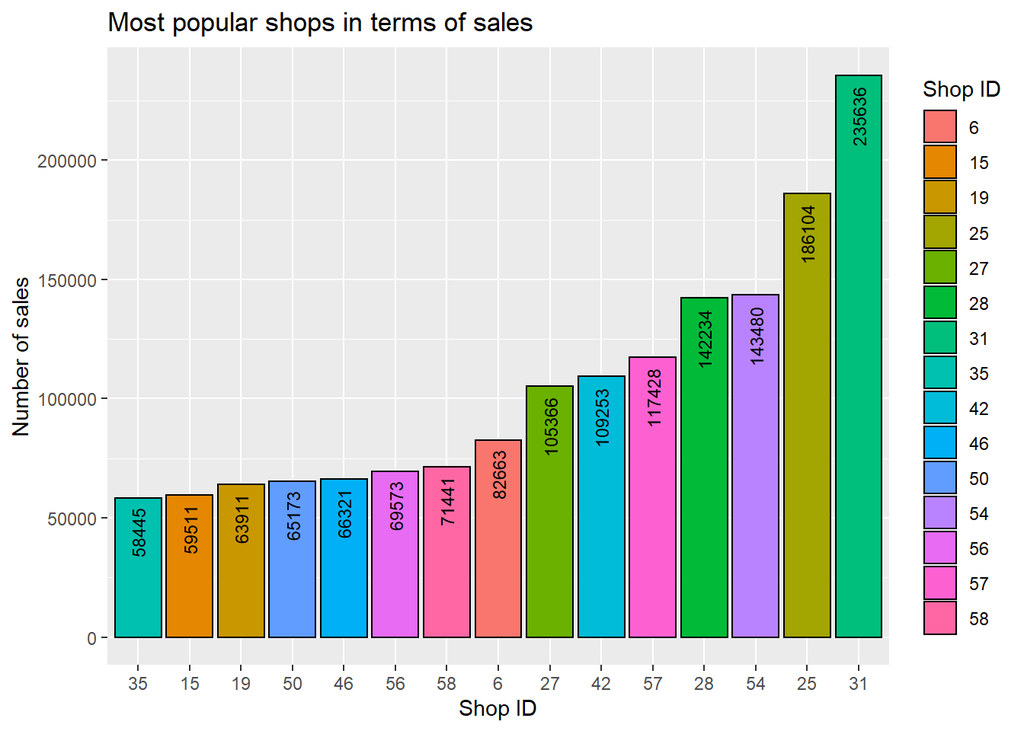

```r
ggplot(data=most_sales_shop,aes(x=reorder(as.factor(shop_id),most_sales_shop_cnt),y=most_sales_shop_cnt,fill=as.factor(shop_id)))+geom_bar(stat="identity",color="Black")+
  labs(x="Shop ID",y="Number of sales",title="Most popular shops in terms of sales",fill="Shop ID")+
  geom_text(aes(label=most_sales_shop_cnt),size=3,angle=90,hjust=1.2)
```

**Shops and their total revenue**

```r
total_revenue_shops=df_sales%>%group_by(shop_id)%>%summarize(revenue=sum(item_price*item_cnt_day))%>%arrange(desc(revenue))%>%head(15)%>%ungroup()
head(total_revenue_shops,10)
```

```
## # A tibble: 10 x 2
##    shop_id    revenue
##      <int>      <dbl>
##  1      31 235217019.
##  2      25 216480571.
##  3      28 159746337.
##  4      42 151917033.
##  5      54 141939673.
##  6      27 140632474.
##  7      57 112999784.
##  8      12 112205073.
##  9       6  98067454.
## 10      18  83392701.
```

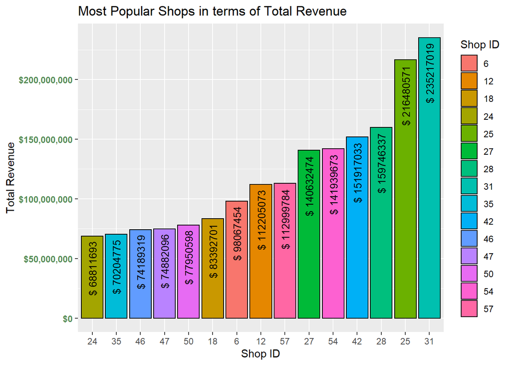

```r
ggplot(data=total_revenue_shops,aes(x=reorder(as.factor(shop_id),revenue),y=revenue,fill=as.factor(shop_id))) +geom_bar(stat = "identity",color="Black") +
  labs(x="Shop ID",y="Total Revenue", title="Most Popular Shops in terms of Total Revenue",fill="Shop ID")+geom_text(aes(label=paste ("$",round(revenue))),size=3.5,hjust=1.1,vjust=.5,angle=90)+
  scale_y_continuous(labels=dollar)+
  theme(axis.text.y=element_text(face="bold",color="palegreen4"))
```

**Shop 31 has got the highest revenue from sales with total grossing amount $235,217,019**

**Total sales by item id**

```r
total_item_sales=df_sales%>%group_by(item_id)%>%summarize(total_sales=sum(item_cnt_day))%>%arrange(desc(total_sales))%>%head(15)%>%ungroup()
head(total_item_sales,10)
```

```
## # A tibble: 10 x 2
##    item_id total_sales
##      <int>       <dbl>
##  1   20949      187642
##  2    2808       17245
##  3    3732       16642
##  4   17717       15830
##  5    5822       14515
##  6    3734       11688
##  7    6675       10289
##  8    3731       10099
##  9    1855       10032
## 10   16787        9227
```

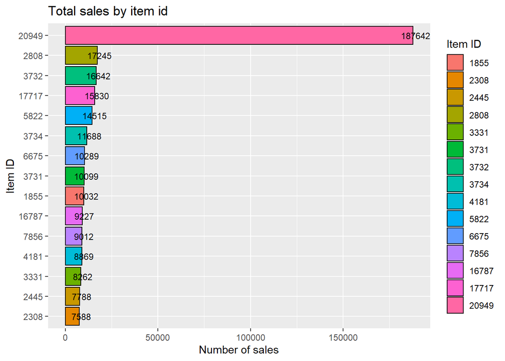

```r
#Visualization
ggplot(data=total_item_sales,aes(x=reorder(as.factor(item_id),total_sales),y=total_sales,fill=as.factor(item_id)))+
  geom_bar(stat="identity",color="Black")+coord_flip()+
  labs(title="Total sales by item id",x="Item ID",y="Number of sales",fill="Item ID")+
  geom_text(aes(label=total_sales),size=3,hjust=0.4)
```

**Item 20949 is the most sold item with 187642 sales**

**Total sales by item category id**

```r
total_category_sales=df_sales%>%group_by(item_category_id)%>%summarize(total_sales=sum(item_cnt_day))%>%arrange(desc(total_sales))%>%head(15)%>%ungroup()
head(total_category_sales,10)
```

```
## # A tibble: 10 x 2
##    item_category_id total_sales
##               <int>       <dbl>
##  1               40      634171
##  2               30      456540
##  3               55      348591
##  4               19      254887
##  5               37      203284
##  6               71      187998
##  7               28      174954
##  8               23      169944
##  9               20      127319
## 10               65       73077
```

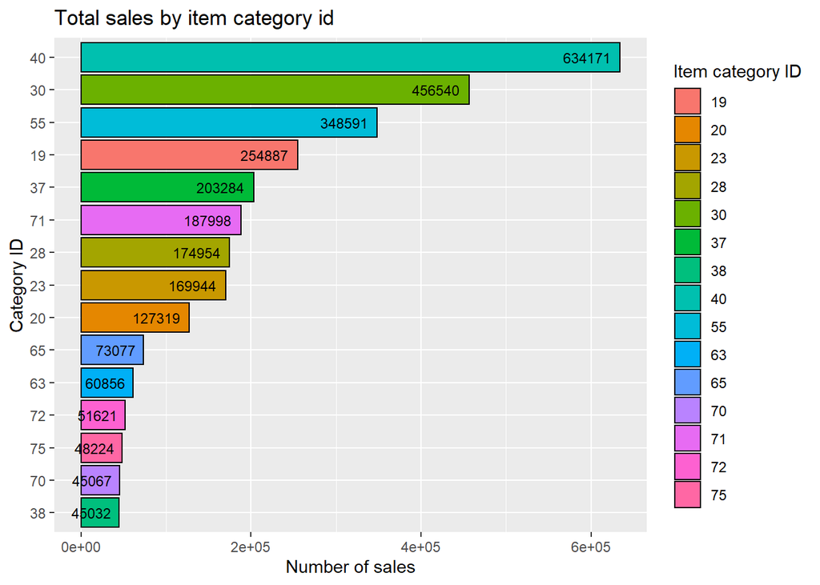

```r
#Visualization
ggplot(data=total_category_sales,aes(x=reorder(as.factor(item_category_id),total_sales),y=total_sales,fill=as.factor(item_category_id)))+
  geom_bar(stat="identity",color="Black")+coord_flip()+
  labs(title="Total sales by item category id",x="Category ID",y="Number of sales",fill="Item category ID")+
  geom_text(aes(label=total_sales),size=3,hjust=1.2)
```

**Items in category 40 have been most sold (634171 sales)**

**Top 15 popular items based on Revenue**

```r
total_revenue_items=df_sales%>%group_by(item_id)%>%summarize(revenue=sum(item_price*item_cnt_day))%>%arrange(desc(revenue))%>%head(15)%>%ungroup()
head(total_revenue_items,10)
```

```
## # A tibble: 10 x 2
##    item_id    revenue
##      <int>      <dbl>
##  1    6675 219391489.
##  2    3732  43617975.
##  3   13443  34331245.
##  4    3734  31065160.
##  5    3733  22298864.
##  6   16787  21907839.
##  7    3731  19983483.
##  8   13405  18125480.
##  9   17717  17200826.
## 10    5823  17151846.
```

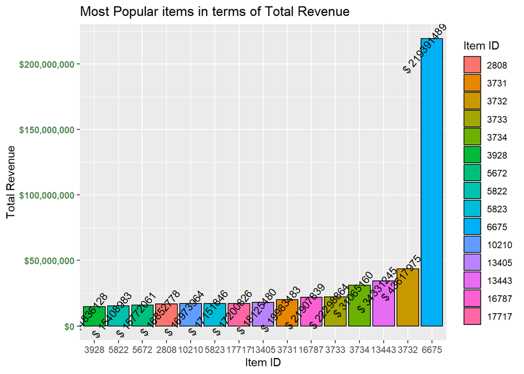

```r
ggplot(data=total_revenue_items,aes(x=reorder(as.factor(item_id),revenue),y=revenue,fill=as.factor(item_id))) +geom_bar(stat = "identity",color="Black") +
  labs(x="Item ID",y="Total Revenue", title="Most Popular items in terms of Total Revenue",fill="Item ID")+geom_text(aes(label=paste ("$",round(revenue))),size=3.5,hjust=0.7,vjust=.5,angle=50)+
  scale_y_continuous(labels=dollar)+
  theme(axis.text.y=element_text(face="bold",color="palegreen4"))
```

**Item 6675 is the most popular item in terms of overall revenue ($219,391,489)**

**Top 15 shops selling item 6675**

```r
total_revenue_shops=df_sales%>%filter(item_id==6675)%>%
  group_by(shop_id)%>%summarize(revenue=sum(item_price*item_cnt_day))%>%
  arrange(desc(revenue))%>%head(15)%>%ungroup()
head(total_revenue_shops,10)
```

```
## # A tibble: 10 x 2
##    shop_id   revenue
##      <int>     <dbl>
##  1      12 14259410.
##  2      25 11492498.
##  3      31 11137995.
##  4      42 10744985.
##  5      27  8765751.
##  6      28  7591286.
##  7      54  7495788
##  8      18  7476223.
##  9      43  6855542.
## 10       6  6633488.
```

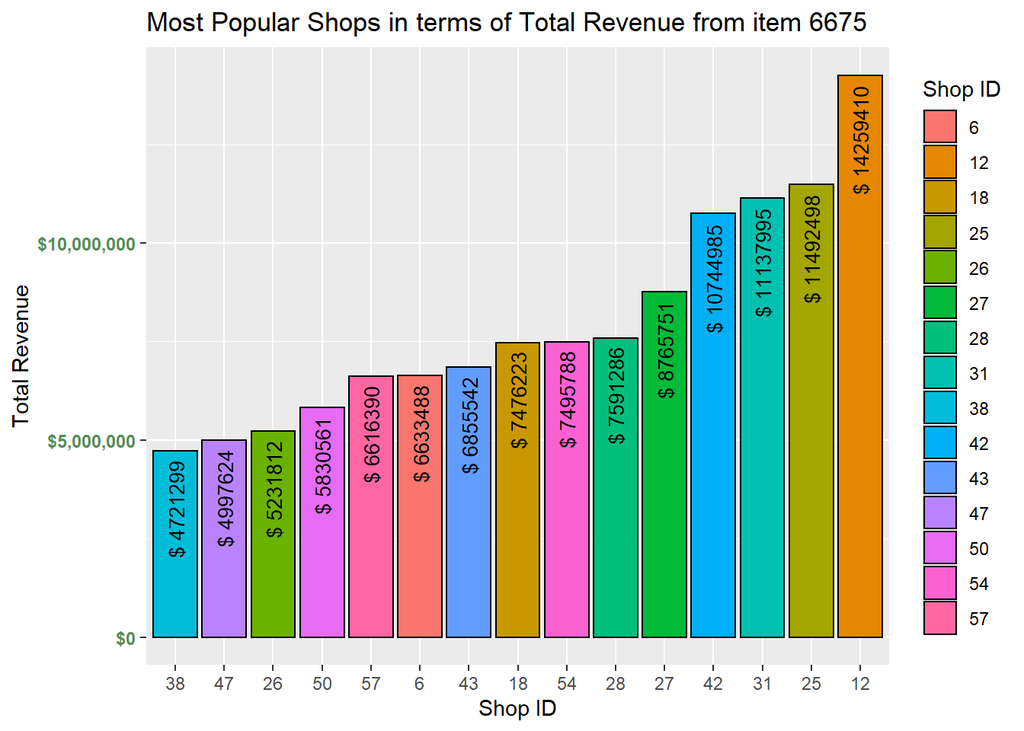

```r
ggplot(data=total_revenue_shops,aes(x=reorder(as.factor(shop_id),revenue),y=revenue,fill=as.factor(shop_id))) +geom_bar(stat = "identity",color="Black") +
  labs(x="Shop ID",y="Total Revenue", title="Most Popular Shops in terms of Total Revenue from item 6675",fill="Shop ID")+geom_text(aes(label=paste ("$",round(revenue))),size=3.5,hjust=1.1,vjust=.5,angle=90)+
  scale_y_continuous(labels=dollar)+
  theme(axis.text.y=element_text(face="bold",color="palegreen4"))
```

**Shop 12 has got the highest turnover from selling item 6675 ($14,259,410)**

**Top 15 popular item categories based on Revenue**

```r
total_revenue_itemcat=df_sales%>%group_by(item_category_id)%>%summarize(revenue=sum(item_price*item_cnt_day))%>%arrange(desc(revenue))%>%head(15)%>%ungroup()
head(total_revenue_itemcat,10)
```

```
## # A tibble: 10 x 2
##    item_category_id    revenue
##               <int>      <dbl>
##  1               19 412050281.
##  2               20 373010312.
##  3               12 292239762.
##  4               23 259619128.
##  5               30 257519291.
##  6               40 169944222.
##  7               28 136419149.
##  8               55 100022564.
##  9               37  90478732.
## 10               75  87085926.
```

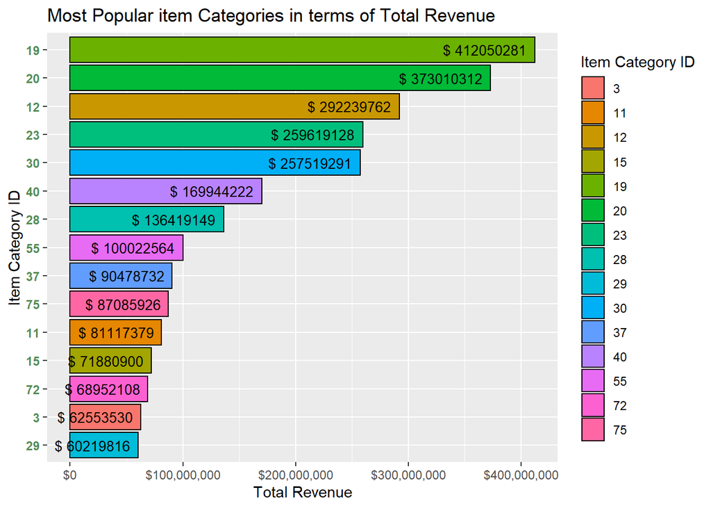

```r
ggplot(data=total_revenue_itemcat,aes(x=reorder(as.factor(item_category_id),revenue),y=revenue,fill=as.factor(item_category_id))) +geom_bar(stat = "identity",color="Black") +
  labs(x="Item Category ID",y="Total Revenue", title="Most Popular item Categories in terms of Total Revenue",fill="Item Category ID")+geom_text(aes(label=paste ("$",round(revenue))),size=3.5,hjust=1.1,vjust=.5)+
  scale_y_continuous(labels=dollar)+coord_flip()+
  theme(axis.text.y=element_text(face="bold",color="palegreen4"))
```

**Item category 19 is the most popular in terms of total revenue ($412,050,281)**

**Top 15 shops selling item category 19**

```r
total_revenue_shops=df_sales%>%filter(item_category_id==19)%>%
  group_by(shop_id)%>%summarize(revenue=sum(item_price*item_cnt_day))%>%
  arrange(desc(revenue))%>%head(15)%>%ungroup()
head(total_revenue_shops,10)
```

```
## # A tibble: 10 x 2
##    shop_id   revenue
##      <int>     <dbl>
##  1      31 26485251.
##  2      25 23391177.
##  3      28 21628610.
##  4      27 17496629.
##  5      54 17122459.
##  6      42 16794875.
##  7      18 16585059.
##  8      50 12561499.
##  9      47 12432501.
## 10       6 11397643.
```

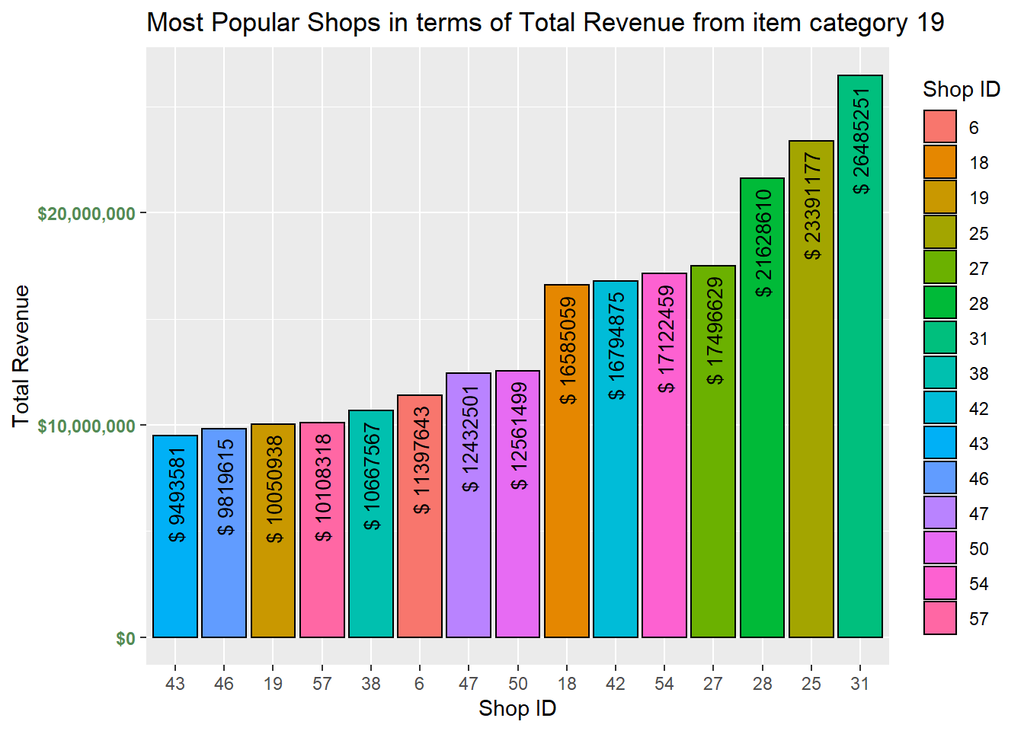

```r
ggplot(data=total_revenue_shops,aes(x=reorder(as.factor(shop_id),revenue),y=revenue,fill=as.factor(shop_id))) +geom_bar(stat = "identity",color="Black") +
  labs(x="Shop ID",y="Total Revenue", title="Most Popular Shops in terms of Total Revenue from item category 19",fill="Shop ID")+geom_text(aes(label=paste ("$",round(revenue))),size=3.5,hjust=1.1,vjust=.5,angle=90)+
  scale_y_continuous(labels=dollar)+
  theme(axis.text.y=element_text(face="bold",color="palegreen4"))
```

**Shop 31 has got the highest turnover from selling item_category 19 ($26,485,251)**

**Year-wise total sales turnover**

```r
total_revenue_year=df_sales%>%
  group_by(year)%>%summarize(revenue=sum(item_price*item_cnt_day))%>%
  ungroup()
total_revenue_year
```

```
## # A tibble: 3 x 2
##   year      revenue
##   <fct>       <dbl>
## 1 2013  1217524734.
## 2 2014  1346778479.
## 3 2015   834623132.
```

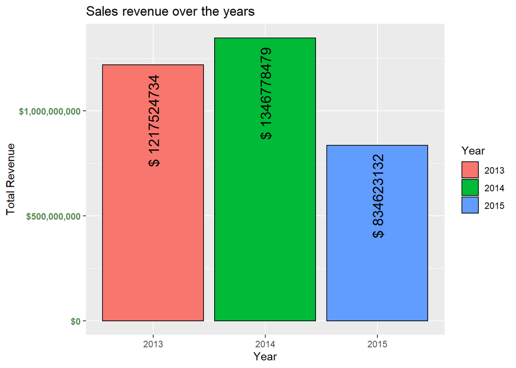

```r
ggplot(data=total_revenue_year,aes(x=year,y=revenue,fill=as.factor(year))) +geom_bar(stat = "identity",color="Black") +
  labs(x="Year",y="Total Revenue", title="Sales revenue over the years",fill="Year")+geom_text(aes(label=paste ("$",round(revenue))),size=5,hjust=1.1,vjust=.5,angle=90)+
  scale_y_continuous(labels=dollar)+
  theme(axis.text.y=element_text(face="bold",color="palegreen4"))
```

```r
total_sales_year=df_sales%>%group_by(year)%>%
  summarize(total_sales=n())%>%ungroup()
total_sales_year
```

```
## # A tibble: 3 x 2
##   year  total_sales
##   <fct>       <int>
## 1 2013      1267562
## 2 2014      1055861
## 3 2015       612426
```

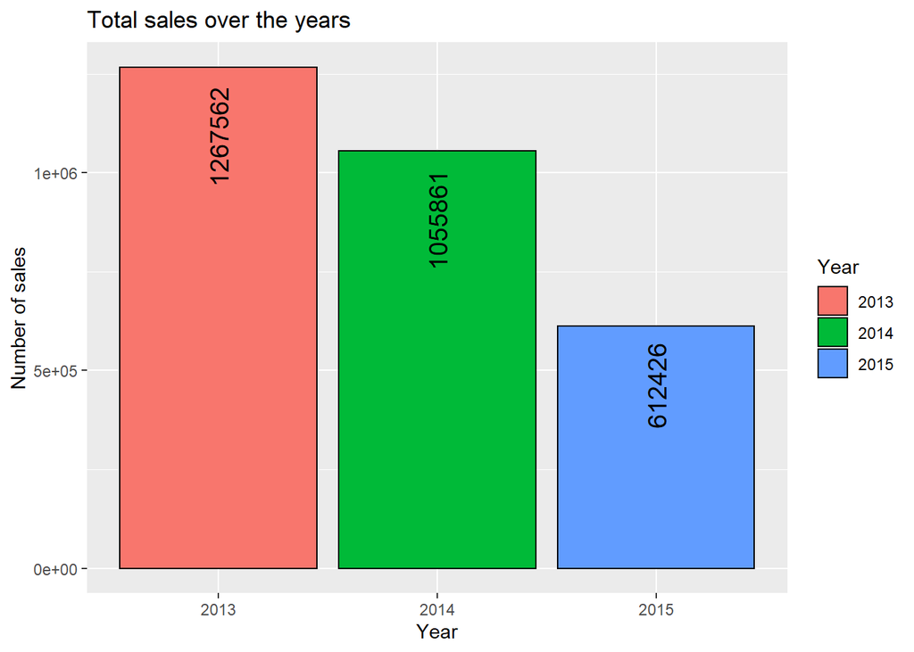

```r
#Visualization
ggplot(data=total_sales_year,aes(x=year,y=total_sales,fill=as.factor(year)))+
  geom_bar(stat="identity",color="Black")+
  labs(title="Total sales over the years",x="Year",y="Number of sales",fill="Year")+
  geom_text(aes(label=total_sales),size=5,hjust=1.2,angle=90)
```

**Month-wise total sales and revenue over all the years combined**

```r
total_revenue_month=df_sales%>%
  group_by(month)%>%summarize(revenue=sum(item_price*item_cnt_day))%>%
  ungroup()
total_revenue_month
```

```
## # A tibble: 12 x 2
##    month    revenue
##    <dbl>      <dbl>
##  1     1 309100814.
##  2     2 284690714.
##  3     3 300524359.
##  4     4 240058855.
##  5     5 244924485.
##  6     6 227616940.
##  7     7 205244308.
##  8     8 225651027.
##  9     9 326710655.
## 10    10 304104248.
## 11    11 290703039.
## 12    12 439596902.
```

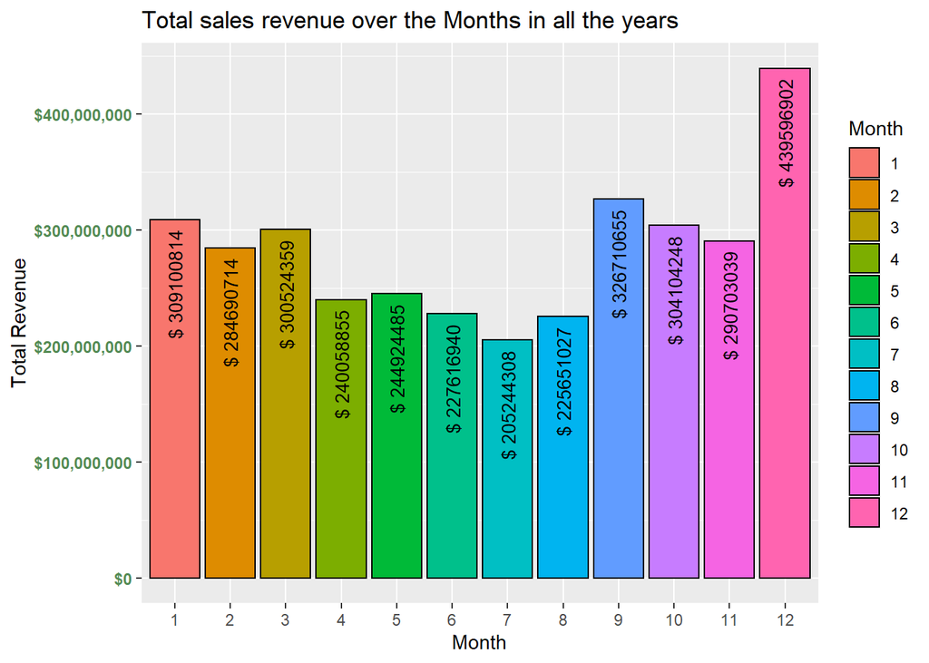

```r
ggplot(data=total_revenue_month,aes(x=as.factor(month),y=revenue,fill=as.factor(month))) +geom_bar(stat = "identity",color="Black") +
  labs(x="Month",y="Total Revenue", title="Total sales revenue over the Months in all the years",fill="Month")+geom_text(aes(label=paste ("$",round(revenue))),size=3.5,hjust=1.1,vjust=.5,angle=90)+
  scale_y_continuous(labels=dollar)+
  theme(axis.text.y=element_text(face="bold",color="palegreen4"))
```

**Total amount of sales over the months in all the years**

```r
total_sales_month=df_sales%>%group_by(month)%>%
  summarize(total_sales=n())%>%ungroup()
total_sales_month
```

```
## # A tibble: 12 x 2
##    month total_sales
##    <dbl>       <int>
##  1     1      303561
##  2     2      270251
##  3     3      284057
##  4     4      228289
##  5     5      224836
##  6     6      237428
##  7     7      234857
##  8     8      248415
##  9     9      219882
## 10    10      227077
## 11    11      183164
## 12    12      274032
```

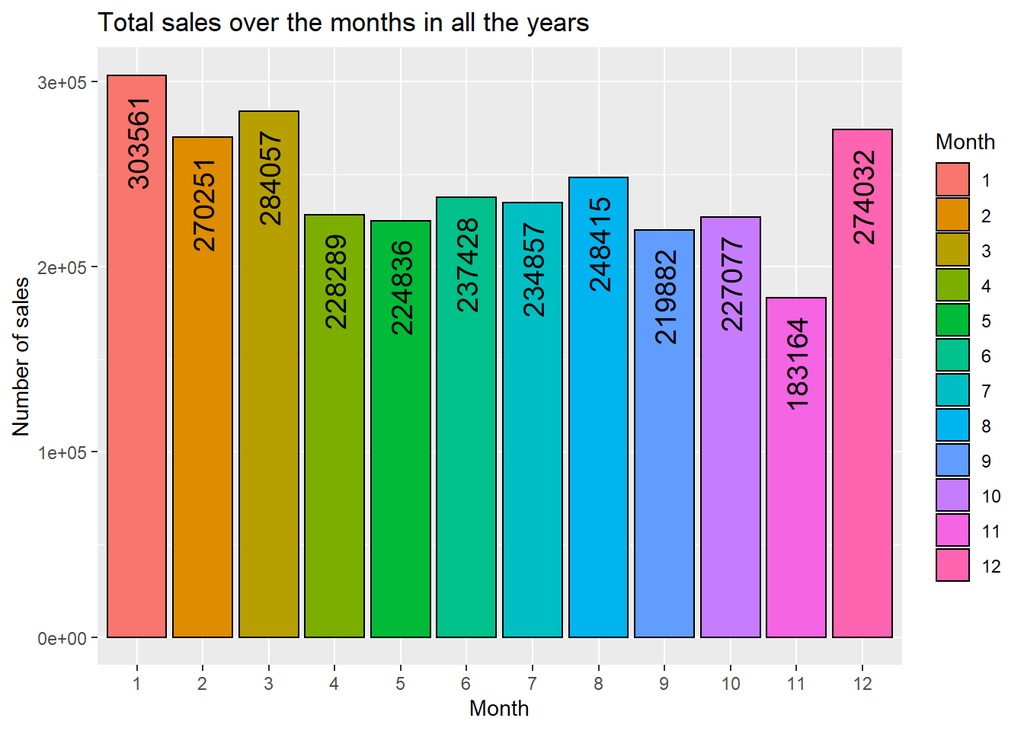

```r
#Visualization
ggplot(data=total_sales_month,aes(x=as.factor(month),y=total_sales,fill=as.factor(month)))+
  geom_bar(stat="identity",color="Black")+
  labs(title="Total sales over the months in all the years",x="Month",y="Number of sales",fill="Month")+
  geom_text(aes(label=total_sales),size=5,hjust=1.2,angle=90)
```

**OVerall Day-wise sales and revenue over all the years**

```r
total_revenue_weekdays=df_sales%>%
  group_by(weekday)%>%summarize(revenue=sum(item_price*item_cnt_day))%>%
  ungroup()
total_revenue_weekdays
```

```
## # A tibble: 7 x 2
##   weekday      revenue
##   <fct>          <dbl>
## 1 Friday    550965178.
## 2 Monday    366401098.
## 3 Saturday  643667826.
## 4 Sunday    515862771.
## 5 Thursday  428062669.
## 6 Tuesday   469872088.
## 7 Wednesday 424094714.
```

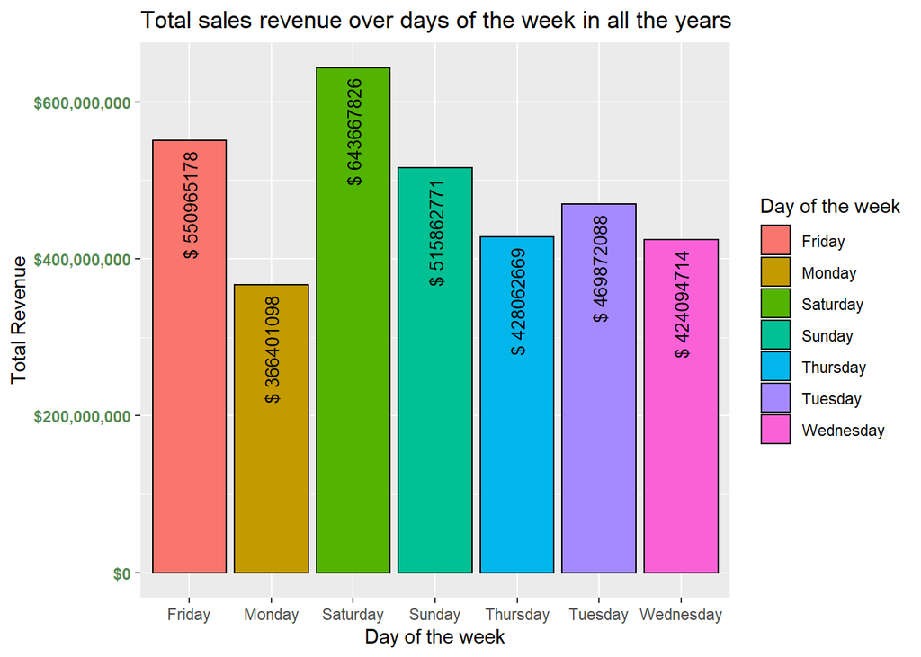

```r
ggplot(data=total_revenue_weekdays,aes(x=as.factor(weekday),y=revenue,fill=as.factor(weekday))) +geom_bar(stat = "identity",color="Black") +
  labs(x="Day of the week",y="Total Revenue", title="Total sales revenue over days of the week in all the years",fill="Day of the week")+geom_text(aes(label=paste ("$",round(revenue))),size=3.5,hjust=1.1,vjust=.5,angle=90)+
  scale_y_continuous(labels=dollar)+
  theme(axis.text.y=element_text(face="bold",color="palegreen4"))
```

**Total sales over the days of the week in all the years combined**

```r
total_sales_weekdays=df_sales%>%group_by(weekday)%>%
  summarize(total_sales=n())%>%ungroup()
total_sales_weekdays
```

```
## # A tibble: 7 x 2
##   weekday   total_sales
##   <fct>           <int>
## 1 Friday         439298
## 2 Monday         337074
## 3 Saturday       590359
## 4 Sunday         503104
## 5 Thursday       367280
## 6 Tuesday        345772
## 7 Wednesday      352962
```

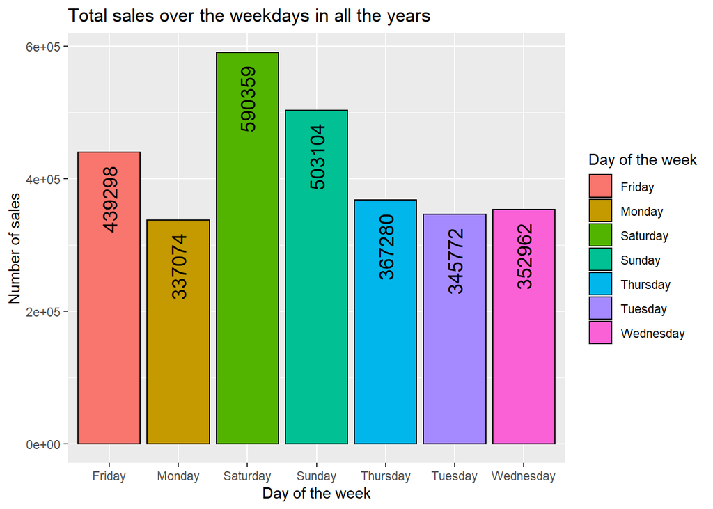

```r
#Visualization
ggplot(data=total_sales_weekdays,aes(x=as.factor(weekday),y=total_sales,fill=as.factor(weekday)))+
  geom_bar(stat="identity",color="Black")+
  labs(title="Total sales over the weekdays in all the years",x="Day of the week",y="Number of sales",fill="Day of the week")+
  geom_text(aes(label=total_sales),size=5,hjust=1.2,angle=90)
```

**Saturday has observed most sales (590359 products) as well as most revenue ($643,667,826). Overall, we can see most products being sold in the weekends while the sales curve is flattened for weekdays**

### **Sales pattern for the year 2014**

**Month-day wise sales in the year 2014**

```r
month_day_sales = df_sales %>% filter(year==2014) %>%
  group_by(month,day) %>% summarize(total_sales=sum(item_cnt_day)) %>% ungroup()
```

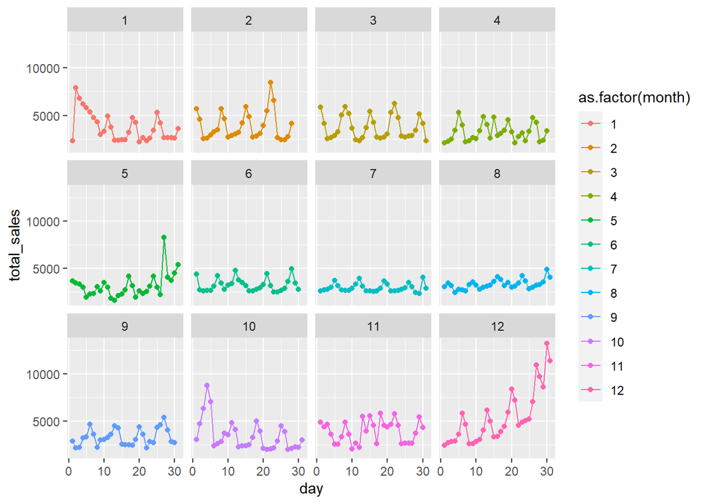

```r
ggplot(data=month_day_sales, aes(x=day, y=total_sales,color=as.factor(month)))+
  geom_line()+
  geom_point()+
  facet_wrap(~month)
```

**The above represents the trend of overall sales month-day wise in the year 2014. We can notice clear spike in sales during early January and December. Thus validating the statements made earlier**

**Top 15 selling items in the year 2014**

```r
most_selling_items = df_sales%>%filter(year==2014)%>%
  group_by(item_id)%>%summarize(total_sales=sum(item_cnt_day))%>%
  arrange(desc(total_sales))%>%head(15)%>%ungroup()
head(most_selling_items,10)
```

```
## # A tibble: 10 x 2
##    item_id total_sales
##      <int>       <dbl>
##  1   20949       85288
##  2   17717        7392
##  3    2814        7096
##  4    5822        6542
##  5    6675        5533
##  6    3733        5322
##  7   16790        5292
##  8    1855        5192
##  9    3928        5116
## 10    9242        4561
```

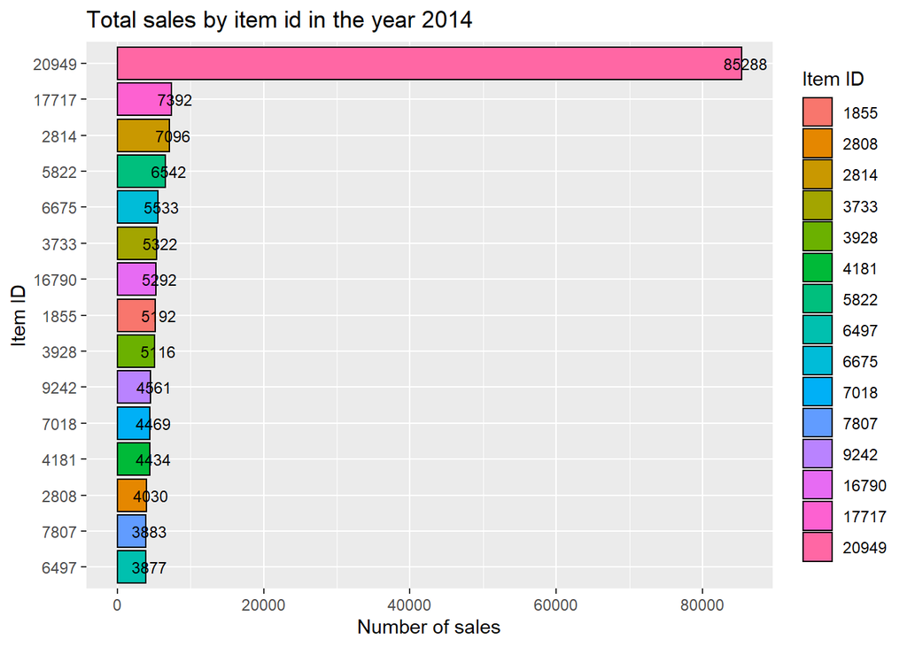

```r
#visualization
ggplot(data=most_selling_items,aes(x=reorder(as.factor(item_id),total_sales),y=total_sales,fill=as.factor(item_id)))+
  geom_bar(stat="identity",color="Black")+coord_flip()+
  labs(title="Total sales by item id in the year 2014",x="Item ID",y="Number of sales",fill="Item ID")+
  geom_text(aes(label=total_sales),size=3,hjust=0.4)
```

**Item 20949 is the most sold item in the year 2014 (85288 sales)**

```r
total_revenue_itemcat=df_sales%>%filter(year==2014)%>%
  group_by(item_category_id)%>%summarize(revenue=sum(item_price*item_cnt_day))%>%
  arrange(desc(revenue))%>%head(15)%>%ungroup()
head(total_revenue_itemcat,10)
```

```
## # A tibble: 10 x 2
##    item_category_id    revenue
##               <int>      <dbl>
##  1               20 181647314.
##  2               12 164821168.
##  3               19 129843156.
##  4               23  98058389.
##  5               30  80806020.
##  6               40  54525125.
##  7               28  53878623.
##  8               55  36213165.
##  9               16  33363918.
## 10                3  32598296.
```

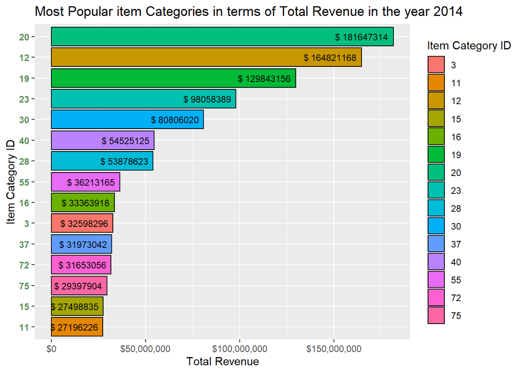

```r
#visualizations
ggplot(data=total_revenue_itemcat,aes(x=reorder(as.factor(item_category_id),revenue),y=revenue,fill=as.factor(item_category_id)))+
  geom_bar(stat = "identity",color="Black")+
  labs(x="Item Category ID",y="Total Revenue", title="Most Popular item Categories in terms of Total Revenue in the year 2014",fill="Item Category ID")+geom_text(aes(label=paste ("$",round(revenue))),size=3,hjust=1.1,vjust=.5)+
  scale_y_continuous(labels=dollar)+coord_flip()+
  theme(axis.text.y=element_text(face="bold",color="palegreen4"))
```

**Category 20 is most grossing in the year 2014 with total revenue $181,647,314**

**Most popular shops in the year 2014 based on item sales**

```r
most_sales_shop=df_sales%>%filter(year==2014)%>%
  group_by(shop_id)%>%summarize(most_sales_shop_cnt=n())%>%arrange(desc(most_sales_shop_cnt))%>%head(15)%>%ungroup()
head(most_sales_shop,10)
```

```
## # A tibble: 10 x 2
##    shop_id most_sales_shop_cnt
##      <int>               <int>
##  1      31               83441
##  2      25               63244
##  3      54               56114
##  4      28               50142
##  5      57               43514
##  6      27               41659
##  7      42               38057
##  8       6               28976
##  9      58               27139
## 10      56               25152
```

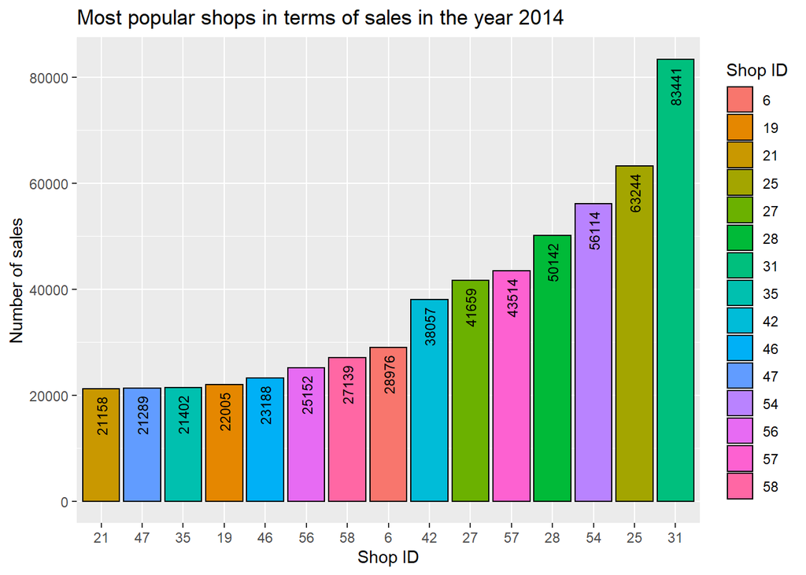

```r
ggplot(data=most_sales_shop,aes(x=reorder(as.factor(shop_id),most_sales_shop_cnt),y=most_sales_shop_cnt,fill=as.factor(shop_id)))+geom_bar(stat="identity",color="Black")+
  labs(x="Shop ID",y="Number of sales",title="Most popular shops in terms of sales in the year 2014",fill="Shop ID")+
  geom_text(aes(label=most_sales_shop_cnt),size=3,angle=90,hjust=1.2)
```

**Shop 31 is most popular in the year 2014 in terms of total sales (83441 sales)**

**Most popular shops in terms of total revenue in the year 2014**

```r
total_revenue_shops=df_sales%>%filter(year==2014)%>%
  group_by(shop_id)%>%summarize(revenue=sum(item_price*item_cnt_day))%>%
  arrange(desc(revenue))%>%head(15)%>%ungroup()
head(total_revenue_shops,10)
```

```
## # A tibble: 10 x 2
##    shop_id   revenue
##      <int>     <dbl>
##  1      31 89003723.
##  2      25 80280419.
##  3      27 63231355.
##  4      54 62977331.
##  5      28 61483427.
##  6      42 54807552.
##  7      57 46679571.
##  8      12 42948168.
##  9       6 37861876.
## 10      43 32276423.
```

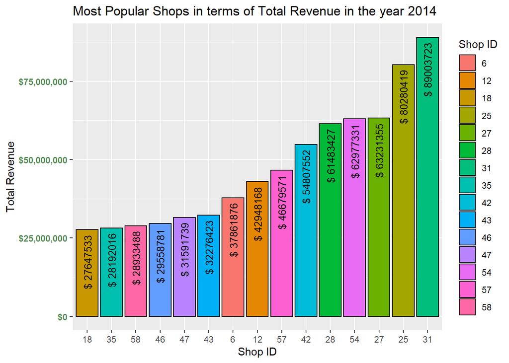

```r
ggplot(data=total_revenue_shops,aes(x=reorder(as.factor(shop_id),revenue),y=revenue,fill=as.factor(shop_id)))+
  geom_bar(stat = "identity",color="Black")+
  labs(x="Shop ID",y="Total Revenue", title="Most Popular Shops in terms of Total Revenue in the year 2014",fill="Shop ID")+geom_text(aes(label=paste ("$",round(revenue))),size=3.5,hjust=1.1,vjust=.5,angle=90)+
  scale_y_continuous(labels=dollar)+
  theme(axis.text.y=element_text(face="bold",color="palegreen4"))
```

**Shop 31 is also most popular in the year 2014 in terms of total revenue ($89,003,723)**

**Sales behavior over a period of time**

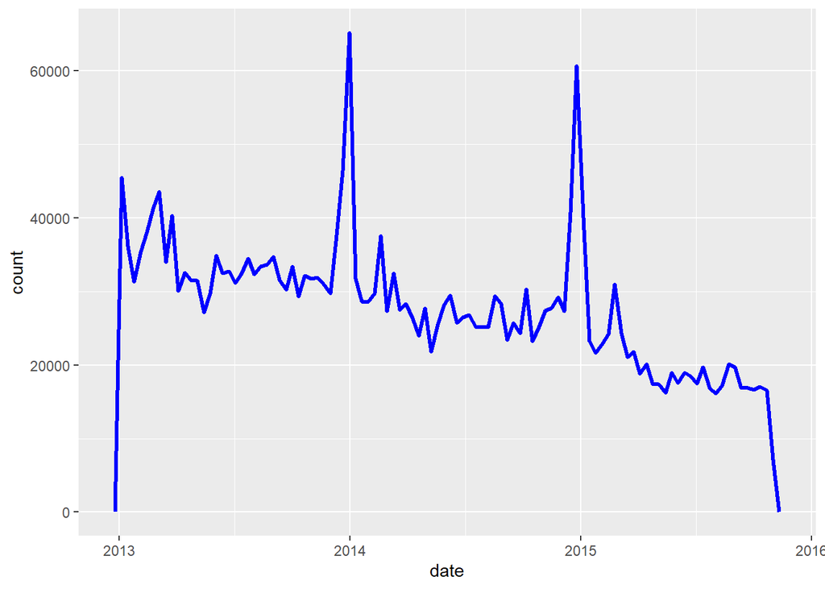

```r
df_sales %>% ggplot(aes(date))+
  geom_freqpoly(color="blue",binwidth=10,size=1.2)
```

**We can notice the highest peak in sales in the year 2014 and another peak in 2015**

**Which month had the highest sales in the year 2014?**

```r
max_sales_2014=df_sales %>% filter(year==2014) %>% group_by(month) %>%
  summarize(max_sales=sum(item_cnt_day)) %>% arrange(desc(max_sales)) %>%
                                                        ungroup()
head(max_sales_2014)
```

```
## # A tibble: 6 x 2
##   month max_sales
##   <dbl>     <dbl>
## 1    12    168755
## 2    11    117845
## 3     1    116899
## 4     3    115297
## 5     2    109687
## 6    10    107422
```

[figure not shown]

```r
ggplot(data=max_sales_2014,aes(x=as.factor(month),y=max_sales,fill=as.factor(month)))+
  geom_bar(stat="identity",color="Black")+
  labs(title="Total sales over the months in the year 2015",x="Month",y="Number of sales",fill="Month")+
  geom_text(aes(label=max_sales),size=5,hjust=1.2,angle=90)
```

**WMax sales occured in the month of December in the year 2014 (168755 products sold)**

**Which month had the highest sales in the year 2015?**

```r
max_sales_2015=df_sales %>% filter(year==2015) %>% group_by(month) %>%
  summarize(max_sales=sum(item_cnt_day)) %>% arrange(desc(max_sales)) %>%
                                                        ungroup()
head(max_sales_2015)
```

```
## # A tibble: 6 x 2
##   month max_sales
##   <dbl>     <dbl>
## 1     1    110971
## 2     2     84198
## 3     3     82014
## 4     4     77827
## 5     9     72843
## 6     5     72295
```

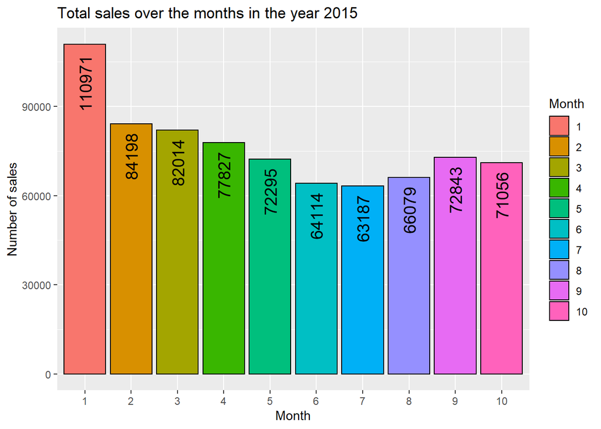

```r
ggplot(data=max_sales_2015,aes(x=as.factor(month),y=max_sales,fill=as.factor(month)))+
  geom_bar(stat="identity",color="Black")+
  labs(title="Total sales over the months in the year 2015",x="Month",y="Number of sales",fill="Month")+
  geom_text(aes(label=max_sales),size=5,hjust=1.2,angle=90)
```

**Max sales occured in the month of January in the year 2015 (110971 products sold)**

**It’s also interesting to note the pattern of increased sales in the months of December and January while taking two consecutive years. This might be due to Winter breaks for Christmas and New Year**

As discussed previously, I could not perform statistical analysis due to the lack of availability of enough factors and continuous variables. Therefore, we will directly proceed to time series forecasting modeling in Review 3, below.

**For time series analysis, we only require date and total amount of products sold per day therefore, we take subset of dataset and convert them to a time series dataset**

```r
#Sorting data according to the date
arrange(df_sales,df_sales$date)
```

```
## # A tibble: 2,935,849 x 12
## # Groups:   year, month, shop_id, item_id [1,609,124]
##    date       date_block_num shop_id item_id item_price item_cnt_day
##    <date>              <int>   <int>   <int>      <dbl>        <dbl>
##  1 2013-01-01              0      19   18976        399            1
##  2 2013-01-01              0      19   18284        199            1
##  3 2013-01-01              0      19   18320        199            1
##  4 2013-01-01              0      19   18329        299            1
##  5 2013-01-01              0      19   19367        399            1
##  6 2013-01-01              0      19   18823        299            1
##  7 2013-01-01              0      19   19413        399            1
##  8 2013-01-01              0      19   19366        399            1
##  9 2013-01-01              0      19   18721        149            1
## 10 2013-01-01              0      19   18638        149            1
## # ... with 2,935,839 more rows, and 6 more variables: item_category_id <int>,
## #   year <fct>, month <dbl>, day <int>, weekday <fct>, item_cnt_month <dbl>
```

**For forecasting total sales in a day, we group the data by date and find aggregate of products sold that day**

```r
df_agg=df_sales%>%group_by(date)%>%summarise(sales_count=sum(item_cnt_day))
df_agg
```

```
## # A tibble: 1,034 x 2
##    date       sales_count
##    <date>           <dbl>
##  1 2013-01-01        1951
##  2 2013-01-02        8198
##  3 2013-01-03        7422
##  4 2013-01-04        6617
##  5 2013-01-05        6346
##  6 2013-01-06        5858
##  7 2013-01-07        4984
##  8 2013-01-08        4772
##  9 2013-01-09        3162
## 10 2013-01-10        3142
## # ... with 1,024 more rows
```

**Converting above dataframe to a time series**

```r
library(xts)
library(forecast)
agg_ts=xts(df_agg$sales_count, order.by = df_agg$date, frequency = 365)
head(agg_ts)
```

```
##            [,1]
## 2013-01-01 1951
## 2013-01-02 8198
## 2013-01-03 7422
## 2013-01-04 6617
## 2013-01-05 6346
## 2013-01-06 5858
```

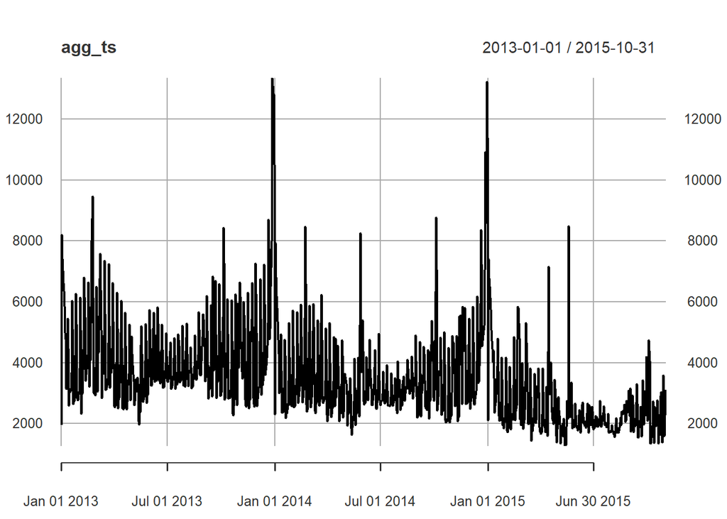

```r
plot(agg_ts)
```

**The above is the time-series plot oft total amount of products sold per day. The data ranges from 1st Jan 2013 to 31st October 2015. Since there are too many records, we will be focusing on most recent sales trend**

```r
#Subset of data in the month of october in the year 2015
df_sub=df_sales%>%group_by(date)%>%filter(date_block_num==33)%>%summarise(sales_count=sum(item_cnt_day))
head(df_sub)
```

```
## # A tibble: 6 x 2
##   date       sales_count
##   <date>           <dbl>
## 1 2015-10-01        2085
## 2 2015-10-02        3265
## 3 2015-10-03        4742
## 4 2015-10-04        4069
## 5 2015-10-05        1340
## 6 2015-10-06        1343
```

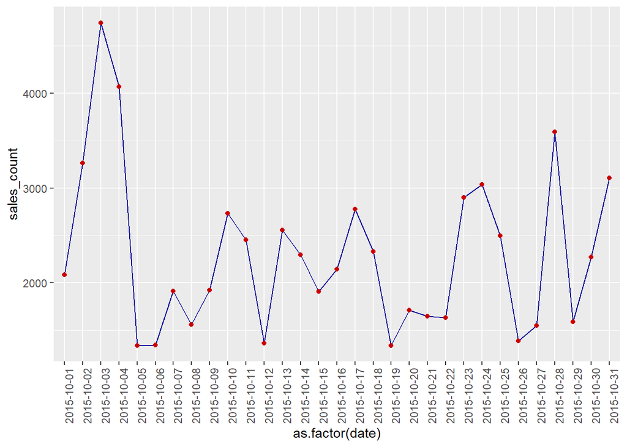

```r
ggplot(df_sub,aes(x=as.factor(date),y=sales_count,group=1))+
  geom_line(colour="#000099")+geom_point(size=1.5,colour="#cc0000")+
  theme(axis.text.x=element_text(angle=90))
```

**Sales line in the month of October 2015**

### **Autoregressive Integrated Moving Average (ARIMA) Model Forecasting**

```r
agg_ts=as.ts(agg_ts)
class(agg_ts)
```

```
## [1] "ts"
```

```r
arima_model <- auto.arima(agg_ts,seasonal.test = "seas")
arima_model
```

```
## Series: agg_ts
## ARIMA(3,1,3)
##
## Coefficients:
##          ar1     ar2      ar3      ma1      ma2     ma3
##       0.2666  0.2299  -0.5135  -0.5288  -0.6208  0.5422
## s.e.  0.1164  0.1185   0.0948   0.1083   0.1265  0.0691
##
## sigma^2 estimated as 1179857:  log likelihood=-8684.47
## AIC=17382.94   AICc=17383.05   BIC=17417.52
```

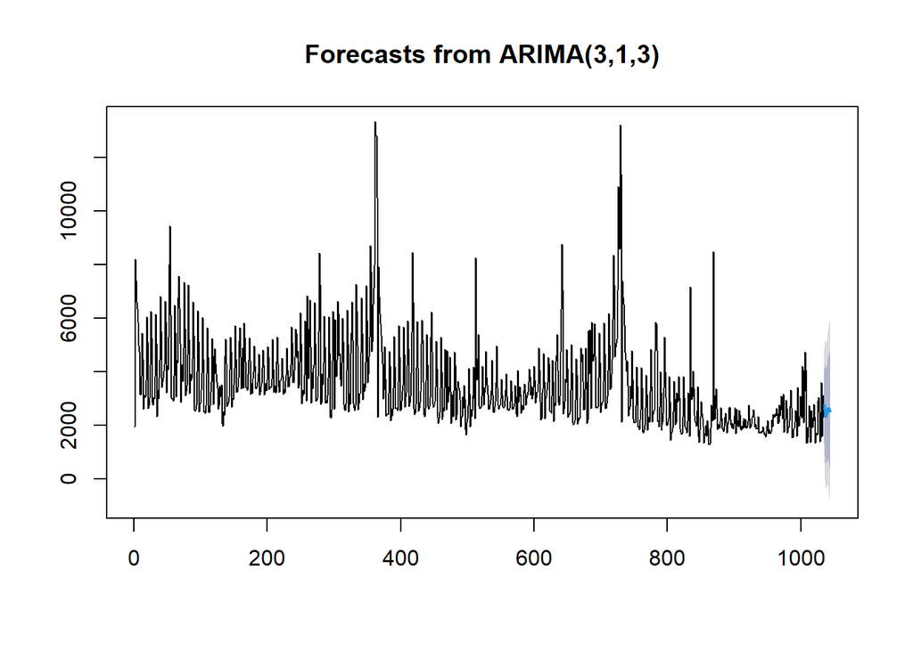

```r
arima_pred1 = forecast(arima_model , h = 30)
arima_pred1 <- as.data.frame(arima_pred1$mean)
plot(forecast(arima_model)) #arima plot
```

Conclusion from the above plot:-  
There is no definite trend in the sales of products. Due to high variability, the model cannot very accurately forecast future sales and the confidence interval is also high. Although there is data available only until October 2015, we can observe a small blue line which is the predicted sales line for the next 30 days which is the month of November in the year 2015. Approximately 2500-3000 products are sold per day in November 2015.